# IODS course project

Tuomas Junna

# Introduction to Open Data Science - Course Project

# About the project

This project consists of coursework completed on the **PHD-302 Introduction to Open Data Science** course. It will consist of weekly assingments that will compiled into a learning diary.

The following project is stored in Github, and can be found can be found from the following URL:  
https://github.com/TSamJ/IODS-project

Everything seems to be in working order with the repository, course diary and local folder being accounted for.

I am feeling like a PhD-student: tired, stressed and equipped with an imposter-syndrome big enough to black out the sun. So everything is in order in that regard. But I am feeling very positive about this course. I have recently started working with big datasets and getting to know R. I hope to learn much more about statistical tests, clustering and dimensionality reduction such as PCA. I’m fairly confident that this course will eventually save me tons of time and even much more nerves, as finding solutions from stackoverflow does very little to actually familiarize a beginner with the root cause of the issues.

I found this course while browsing the uni course catalogue in hopes of finding something that is actually relevant for me at this point. And this is exactly what I needed although I do worry that this could go, like so many coding courses do, right back to the endless stackoverflow swamp when the pace picks up.

Personally, I feel slightly sceptical about the R markdown: it seems like a somewhat convoluted way of achieving relatively little of use at this point. And also much like a tool that I would never personally use in context of scientific research and publication. It’s a bit like writing a document in latex in the sense that it’s a tool with some potential and I can see use cases where it would become extremely handy, but is such a niche use, that more common approaches are usually just easier. I have hard time imaging a situation where I would like to have a ready made word or pdf instead of a separate images/ plots that I can then use in whatever text editor I choose.

This combined with github, that I would personally rename as “the dark, sad pit of dysfunctionality and despair” makes it obvious that making sense of github will be the main early challenge of this course.

The R for Health Data Science looks extremely promising at this point. The chapters so far have been intuitive and the syntax has been explained if not well, atleast much better than in most tutorials one easily runs into while using search engines. The topics relevant to me in my own work that were present in the early chapters I was previously mostly familiar with but I was happy to get a better grasp of the reasoning behind some commands/ functionality. And some new solutions as well that will hopefully help me to speed up my workflow. I do not know how the book compares to stack overflow. Naturally, it will be less hands on and thus slightly less effective as a learning tool, but then again, I believe that in the long run it will serve as a much nicer resource to refer back to. So far, I’ve mostly appreciated the somewhat good explanations between different basic commands, but feel they could do more here. For example `case_when` is ignored but highly useful. Also, can I do conditional statements between two dataframes without joining? Is there a workaround to get multiple values on the same axis with unique free scales?

Index.Rmd has been updated with the author name. Would this not be a more logical place for the github link?

I followed the instruction and generated a new token. However, as I had previously generated a token during the initial setup of Git / Rstudio interaction, I already had an associated token password and was able to push to git prior to completing the step. Thus I was not able to give the password to the console, just review my previously set token.

Test pushes have been succesful.

The results are hopefully visible, if github ever updates.

# Data wrangling, regression and model validations

## Data wrangling

I started with the data wrangling assignment prior to opening the Exercise2 practice set, so initially my solutions were slightly different compared to those depicted to those in the exercise. However, I did learn that in the future I will check out the exercises first in order to save a lot of time wondering what the assignment description is asking for.

*The produced R script can be found from my Github with the name Assignment2_data_Junna.R and the created dataset is named learning_2014.csv to differentiate from the learning2014.csv dataset provided in the exercise.

I started by reading in the relevant libraries (dplyr and tidyverse), creating the data folder into my IODS project and setting the working directory to my IODS project folder using `setwd()`. Then I read in the data from the internet using

`df <- read.delim("http://www.helsinki.fi/~kvehkala/JYTmooc/JYTOPKYS3-data.txt", header = TRUE, sep = "\t")`

A different function from the `read.table()` present in the exercises, but it turned out working none the less. However, I am unclear what the fundamental differences between these are.

Whenever I see a new dataset, there are few checks I like to do. Typically, I initially check it using the `head(df, 10)` function, just to get an idea of what I am dealing with. My next step was to check the structure of the data using `str()` to see if I was dealing with a multitude of data types. Luckily, apart from gender, all integers here. Next I wanted to know if there are any gaps in the data by using `na.rm(df)` I believe this is the first time I actually a complete dataset loaded in R without making it happen! Nice!

I proceeded to check the headers using `head()` and briefly wondered about the possibility of whether this is a gender binary data by checking `n_distinct(df$gender)`. I did a DF `summary()` and concluded that this is likely survey data (or normalized values due to most being between 1 and 5). Last and definitely least, I checked the dimension of the dataset using the `dim()` funtion. As predicted, it did match the dimensions that were displayed in the environment window of Rstudio with 183 observations of a total 60 variables.

I scaled down the Attitude points using a pipe, as that somehow is my go to solution even if I do just one thing. I simply prefer the syntax over spilling dollar signs everywhere. So I did:

`df <- df %>%` `mutate(attitude = (Attitude /10))`

I then stopped wasting time and opened the exercise sheet. As I did the exercises, I was very impressed to realize that we had the relevant values picked for all combination groups of deep, strategic and surface questions. I very much appreciate the fact that we did not have to spend time picking these from some apocryphal metadata file. Thank you exercise designer!

So the variables very grouped together using `element <- c(1,2,5,etc)` , the element was selected using `select()` with the superseded selection helper `one_of` targeting the previously created element. The end result was scaled to a mean value of all grouped variables using the `mean` and the mean of all grouped variables were included into the DF as new variables names deep, surf and strat. I found this a fairly eloquent solution as I would’ve probably hit the problem with some kind of a pipe again.

Last, the headers were tidied by removing some unnecessary capital letters in the header using `colnames()`, filtered out the variables where values were 0 by using `filter(df, points > 0)` and a separate df for males was created by filtering for the character `filter(df, gender == "M")`. The latter has not been used so far.

The end result is a dataframe with dimensions 166 observations in 7 variables, as was the target. It has uniform lack of capital letters in the headers, simple and quick to write header titles, no gaps and apart from gender, double precision floating point and integer data in nice form with no missing values.

As the working directory was set in the beginning of the script, the data was saved by `write_csv(learning2014, file = "data/learning_2014.csv")` , read back into Rstudio by `df_test <- read_csv("data/learning_2014.csv")` and checked for structure and headers to make sure everything was in order.

To reflect back on the data wrangling exercise, I found it made me spend my time well and the exercise was nice in that was simple, quick and educational. It put effort into tidy and good data practices. I personally did not feel I gained much out of this one as I’ve spent the last 8 months wrangling a horrendous, problem riddled dataset collected over 20 years in various studies into some kind of form, so I kind of knew what to do here beforehand. However, I did like some solutions here that I personally would’ve done differently just out of habit and lack of R training. Had I known these solutions beforehand, they would’ve likely grown into my R “go-to” commands earlier. Then again, had I known what I know about my data, I might’ve become a Subway Sandwich artist instead of a PhD student…

## Regression and model validation

I started this part of the exercise loading the instructed dataset from the internet. While I could’ve used the dataframe previously created, I find it best practice to use a verified source in case something goes haywire (wrong delianeator or some such thing. )

```r
#Add some libraries

library(tidyverse)
```

```r
library(dplyr)
library(readr)
library(ggplot2)
library(GGally)
#Read data into a frame called learning2014

learning2014 <- read.table("https://raw.githubusercontent.com/KimmoVehkalahti/Helsinki-Open-Data-Science/master/datasets/learning2014.txt",
                            sep = ",", header = T)

#Check the structure and dimensions of the dataframe

str(learning2014)
```

```
## 'data.frame':    166 obs. of  7 variables:
##  $ gender  : chr  "F" "M" "F" "M" ...
##  $ age     : int  53 55 49 53 49 38 50 37 37 42 ...
##  $ attitude: num  3.7 3.1 2.5 3.5 3.7 3.8 3.5 2.9 3.8 2.1 ...
##  $ deep    : num  3.58 2.92 3.5 3.5 3.67 ...
##  $ stra    : num  3.38 2.75 3.62 3.12 3.62 ...
##  $ surf    : num  2.58 3.17 2.25 2.25 2.83 ...
##  $ points  : int  25 12 24 10 22 21 21 31 24 26 ...
```

```r
head(learning2014)
```

```
##   gender age attitude     deep  stra     surf points
## 1      F  53      3.7 3.583333 3.375 2.583333     25
## 2      M  55      3.1 2.916667 2.750 3.166667     12
## 3      F  49      2.5 3.500000 3.625 2.250000     24
## 4      M  53      3.5 3.500000 3.125 2.250000     10
## 5      M  49      3.7 3.666667 3.625 2.833333     22
## 6      F  38      3.8 4.750000 3.625 2.416667     21
```

```r
summary(learning2014)
```

```
##     gender               age           attitude          deep
##  Length:166         Min.   :17.00   Min.   :1.400   Min.   :1.583
##  Class :character   1st Qu.:21.00   1st Qu.:2.600   1st Qu.:3.333
##  Mode  :character   Median :22.00   Median :3.200   Median :3.667
##                     Mean   :25.51   Mean   :3.143   Mean   :3.680
##                     3rd Qu.:27.00   3rd Qu.:3.700   3rd Qu.:4.083
##                     Max.   :55.00   Max.   :5.000   Max.   :4.917
##       stra            surf           points
##  Min.   :1.250   Min.   :1.583   Min.   : 7.00
##  1st Qu.:2.625   1st Qu.:2.417   1st Qu.:19.00
##  Median :3.188   Median :2.833   Median :23.00
##  Mean   :3.121   Mean   :2.787   Mean   :22.72
##  3rd Qu.:3.625   3rd Qu.:3.167   3rd Qu.:27.75
##  Max.   :5.000   Max.   :4.333   Max.   :33.00
```

The dataframe appears to be identical to the one I have previously created and described with 166 observations in 7 variables. Apart from gender being represented by either M of F character, it contains numerical values with integers in variables “age” and “points” and double float point numerics in variables in “attitude”, “deep”, “stra” and “surf”. The variables “age” and “gender” are relatively self explanatory, but essentially this is survey query data where points from certain questions were grouped together and normalized to represent different types of learning and attitude towards learning such as strategic learning and planning, surface learning, deep learning and general attitude. These double floating point values range between 1 and 5. The points category is the exam scores ranging between 7 and 33, with median score being 23.

Next are some graphical representations of the data. Lets see about the age distribution first:

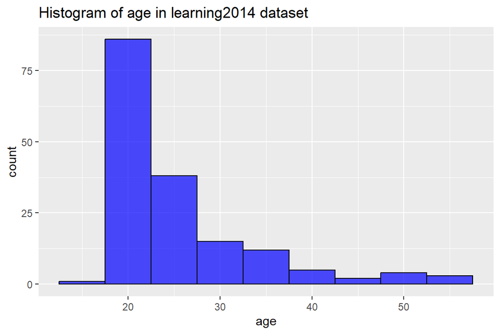

```r
ggplot(learning2014, aes(x = age)) +
  geom_histogram(binwidth = 5, fill = "blue", color = "black", alpha = 0.7) +
  ggtitle("Histogram of age in learning2014 dataset")
```

As we can see, the dataset is heavily representing people in their 20’s, with maximum age being 55 years old. This is also seen where the median age of study subjects is 22, the mean age is 25 and half years.

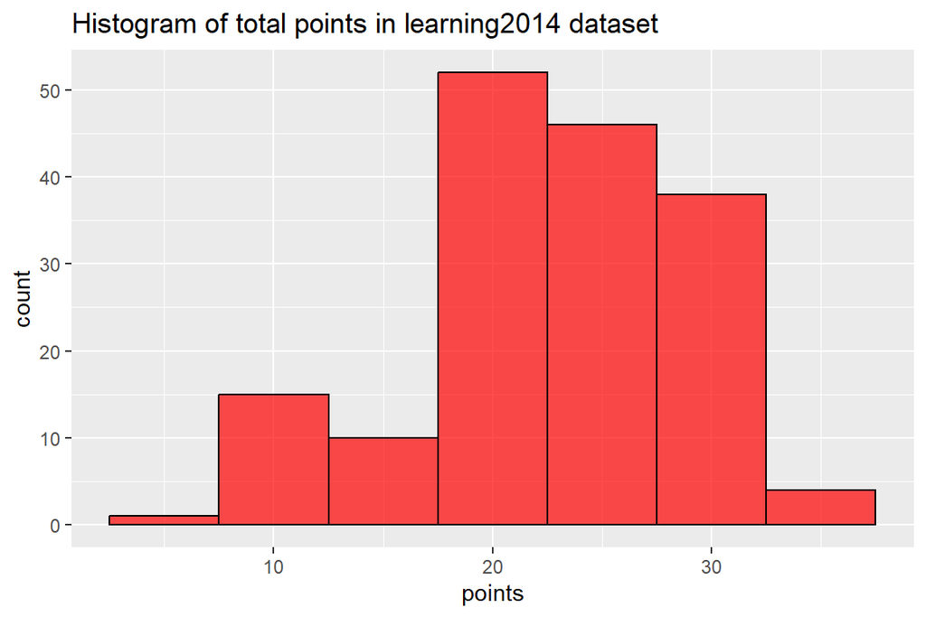

```r
ggplot(learning2014, aes(x = points)) +
  geom_histogram(binwidth = 5, fill = "red", color = "black", alpha = 0.7) +
  ggtitle("Histogram of total points in learning2014 dataset")
```

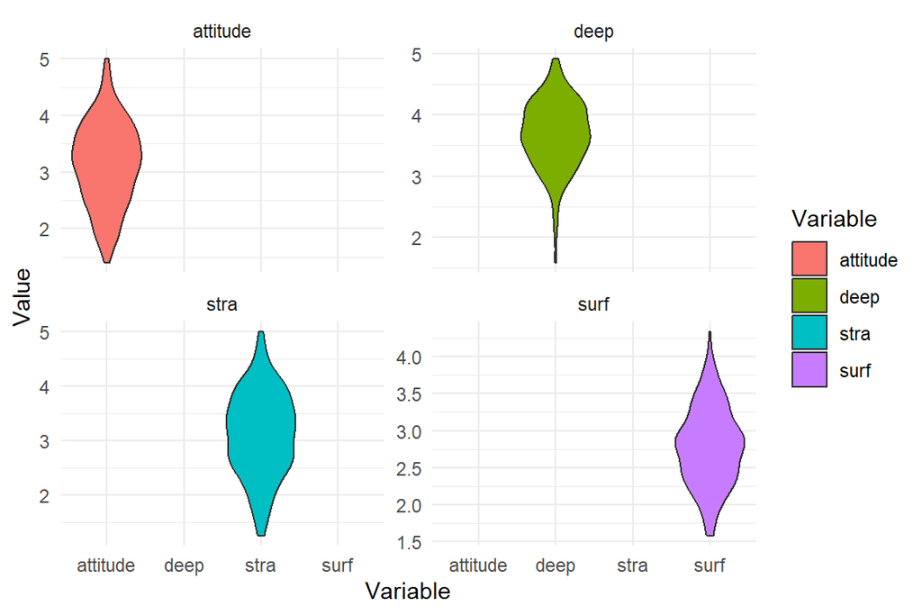

```r
#Compare the summaried variables

#Select variables into their own dataframe
df_learn <- learning2014 %>%
  select(attitude, deep, stra, surf)

# Reshape the data from wide to long format using gather
data_long <- gather(df_learn, key = "Variable", value = "Value")

# Create a violin plot using ggplot2
ggplot(data_long, aes(x = Variable, y = Value, fill = Variable)) +
  geom_violin() +
  facet_wrap(~Variable, scales = "free_y", ncol = 2) +
  theme_minimal()
```